# VLPBEK_2025_20240115_99XX.csv

Beschrijving Bekostigingsbestand

# 1 Inleiding

Dit document beschrijft de inhoud van het bekostigingsbestand “VLPBEK_2025_20240115_99XX.csv”.  
DUO omschrijft dit als een analysebestand voor één instelling, in dit geval voor 99XX, this HEI.

In het *Programma van Eisen Elektronische gegevensuitwisseling tussen HO-instellingen en de Dienst Uitvoering Onderwijs* geeft DUO aan:

- Dit analysebestand bevat van alle inschrijvingen (deelnames) en graden (resultaten) die van belang zijn voor het betrokken bekostigingsjaar het resultaat van de bepaling van de bekostigingstatus met de daarbij horende grondslag.
- Het doel van dit bestand is om gedetailleerd inzicht te geven in welke deelnames en resultaten worden bekostigd en indien ze niet worden bekostigd, waarom niet. Het analysebestand kan gebruikt worden voor analysedoeleinden.

Wij analyseren dit bestand met het doel inzicht te krijgen in wisselstroom en stapelstroom.

## 1.1 Rapportage keuzes

Dit is een gegenereerd bestand, op basis van een aantal keuzes:

- het bekostigingsbestand VLPBEK_2025_20240115_99XX.csv
- de eigen BRIN wordt weergegeven met label **this HEI**
- andere hoger onderwijs instellingen met label **other HE**

## 1.2 Betekenis bestandsnaam

Naast de inhoud, bevat de **naam** van het bestand (“VLPBEK_2025_20240115_99XX.csv”) ook informatie:

- VLPBEK: betreft voorlopige bekostiging
- 2025: het bekostigingsjaar
- 20240115: aanmaakdatum van het bestand in yyyymmdd
- 99XX: de brin van de instelling waarvoor dit bestand is gemaakt

## 1.4 Bewerking

Om tot de wissel- en stapelstroom inzichten te komen, is eerst het bekostigingsbestand uit elkaar getrokken zodat alle regels over inschrijvingen in een losse dataset komen, en alle regels over behaalde graden in een andere dataset. Niet alle velden zijn daarbij meegenomen, alleen die relevant zijn voor de inzichten. Hierbij wordt het academisch jaar bepaald door de inschrijfdatum of de datum waarop de graad is behaald. Deze losse data sets zijn beschikbaar voor een eigen analyse.

Het komt voor dat studenten in hetzelfde academische jaar meerdere inschrijvingen hebben voor dezelfde combinatie brin / croho. Voor de wissel- en stapelstroom inzichten worden deze samengevat tot één regel waarvan de startdatum wordt gezien als de vroegste startdatum van onderliggende inschrijvingen, en de vertrekdatum als de laatste stopdatum van de onderliggende inschrijvingen. Soms is een onderliggende inschrijving voor een andere lesvorm (VT, DT, DU) dan een andere. Dit wordt dan samengevat door ze samen te nemen (bijvoorbeeld DT|DU). In het vervolg wordt met “inschrijving’ deze samengevatte inschrijving bedoeld. Bij dit bestand komt dat neer op:

- 83 inschrijvingen door 80 studenten in 2022/2023
- 80 inschrijvingen door 80 studenten in 2023/2024

Voor elke inschrijving wordt bepaald wat voor soort stroom het betreft. Dit wordt behalve door deze inschrijving, ook door de andere inschrijvingen van deze student bepaald:

- voor inschrijvingen in 2022/2023 kan dat een stay, switch, stack, stop of special zijn,
- voor inschrijvingen in 2023/2024 kan dat een start, stay, switch, stack of special zijn.

# 2 Globale stromen

In Afbeelding 1 worden de stromen studenten tussen de academische jaren gevisualiseerd. In Tabel 1 staan de aantallen. Dit is een weergave van alle inschrijvingen.

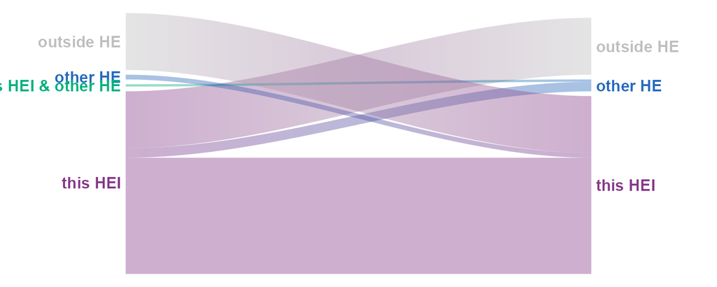

Afbeelding 1: Globale stromen van studenten tussen de twee academische jaren. Links wordt het academische jaar 2022/2023 weergegeven, rechts 2023/2024

Tabel 1: Studentenstromen in het bekostigingsbestand

| in 2022/2023 | in 2023/2024 this HEI | in 2023/2024 other HE | in 2023/2024 outside HE | in 2023/2024 totaal |
| --- | --- | --- | --- | --- |
| this HEI | 49 | 4 | 24 | 77 |
| this HEI & other HE | - | 1 | - | 1 |
| other HE | 2 | - | - | 2 |
| outside HE | 24 | - | - | 24 |
| totaal | 75 | 5 | 24 | 104 |

## 2.1 Stay, switch, stack, stop of special

Na het jaar 2022/2023 switcht 7.6% van de 79 inschrijvingen van de 78 studenten van this HEI, zie Tabel 2 .

Tabel 2: Stromen van this HEI in 2022/2023 naar bestemming (niet per se naar this HEI) in 2023/2024

| stroom | aantal | deel |
| --- | --- | --- |
| stay | 46 | 58.2% |
| stop | 25 | 31.6% |
| switch | 6 | 7.6% |
| special | 1 | 1.3% |
| stack | 1 | 1.3% |
| totaal | 79 | 100.0% |

## 2.2 Wisselstromen

Van de 6 switchende inschrijvingen van studenten van this HEI, wordt in Tabel 3 weergegeven of dat binnen of buiten de eigen instelling is. Ook wordt onderscheid gemaakt tussen switch met en zonder propedeuse diploma.

Tabel 3: Switchende studentenstromen van this HEI in 2022/2023 naar bestemming (niet per se naar this HEI) in 2023/2024

| na 2022/2023 | propedeuse | in 2023/2024 switch naar this HEI | in 2023/2024 switch naar other HE | in 2023/2024 switch naar this HEI & other HE | in 2023/2024 switch naar totaal |
| --- | --- | --- | --- | --- | --- |
| 2022/2023 | zonder propedeuse | 3 | 3 | - | 6 |
| totaal | - | 3 | 3 | - | 6 |

In Afbeelding 2 staat de verdeling van de switchende stromen weergegeven.

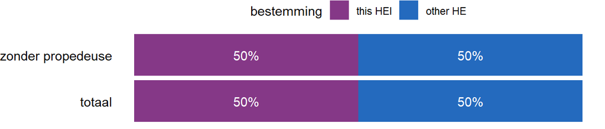

Afbeelding 2: Verdeling van switchstromen van this HEI in 2022/2023 over bestemming (niet per se naar this HEI) in 2023/2024

Van de 0 inschrijvingen met een propedeuse die switchen naar een andere instelling, gaat 0% naar een instelling in het hbo en 0% naar het wo.

## 2.3 Stapelstromen

Na het behalen van een diploma bij this HEI beginnen de studenten van 1 inschrijvingen aan een andere studie. In Tabel 4 is de verdeling naar behaald diploma te zien in aantallen, en in Afbeelding 3 in percentages.

Tabel 4: Stapelende studentenstromen van this HEI in 2022/2023 naar bestemming (niet per se naar this HEI) in 2023/2024

| na 2022/2023 | na het behalen van diploma<sup>1</sup> | in 2023/2024 stapelen bij other HE | in 2023/2024 stapelen bij this HEI | in 2023/2024 stapelen bij this HEI & other HE | in 2023/2024 stapelen bij totaal |
| --- | --- | --- | --- | --- | --- |
| 2022/2023 | B | 1 | - | - | 1 |
| totaal | - | 1 | - | - | 1 |

<sup>1</sup> A = Associate Degree, B = Bachelor, DB = Propedeuse & Bachelor, M = Master

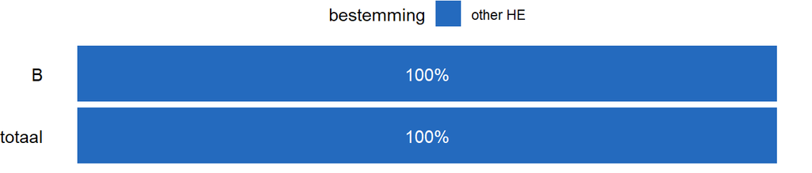

- Van de 1 inschrijvingen met een B diploma, die aan een andere instelling gaan doorstuderen, gaat 100% naar het wo

# 3 Detail stromen

## 3.1 Wisselstromen vanuit this HEI

Tabel 5 geeft de wissels weer die minstens 10 keer zijn voorgekomen.

Tabel 5: Wisselstromen van this HEI in 2022/2023 naar 2023/2024 met een minimale omvang van 10

| van | van | naar | naar | totaal switch | waarvan met propedeuse diploma |
| --- | --- | --- | --- | --- | --- |
| studiejaar | opleiding | studiejaar | inschrijving |  |  |

## 3.2 Stapelstromen vanuit this HEI

Tabel 6 geeft de wissels weer die minstens 10 keer zijn voorgekomen.

Tabel 6: Stapelstromen van this HEI in 2022/2023 naar 2023/2024 met een minimale omvang van 10

| van | van | van | naar | naar | totaal stapelaars |
| --- | --- | --- | --- | --- | --- |
| studiejaar | type | opleiding | studiejaar | inschrijving |  |

# Colofon

Deze beschrijving is een via R-code gegenereerd rapport.  
De code is opgesteld door Martine Jansen, institutional researcher bij Fontys Hogeschool.